# Random forests & bagging

## Exercise 7: Classification regions

Just like any classification model, forests divide our data points into classification regions. Let’s explore this idea using some *simulated* data that illustrate some important contrasts.[^1] Import and plot the data:

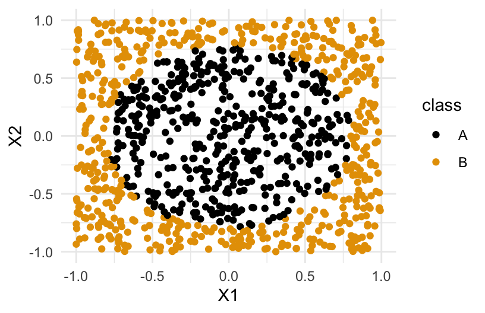

```r
# Import data
simulated_data <- read.csv("https://kegrinde.github.io/stat253_coursenotes/data/circle_sim.csv") %>%
  mutate(class = as.factor(class))

# Plot data
ggplot(simulated_data, aes(y = X2, x = X1, color = class)) +
  geom_point() +
  theme_minimal()
```

1. Below is a classification **tree** of `class` by `X1` and `X2`. What do you think its classification regions will look like?

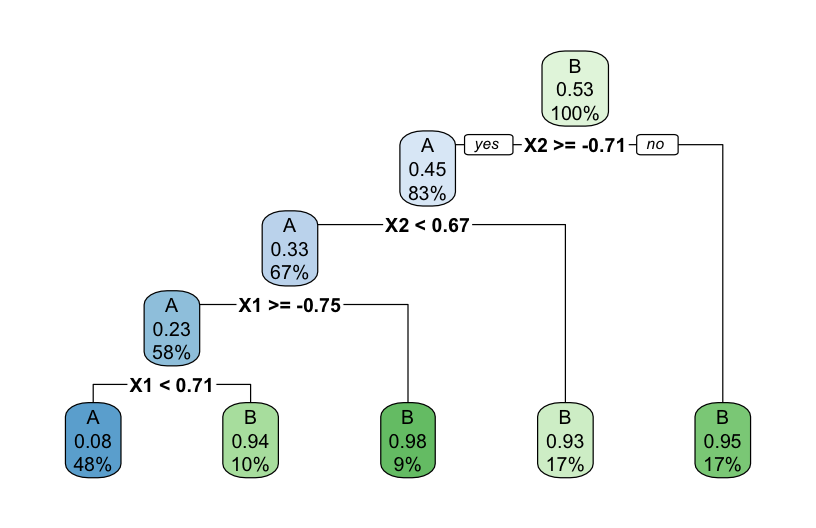

```r
# Build the (default) tree
circle_tree <- decision_tree() %>%
  set_mode("classification") %>%
  set_engine(engine = "rpart") %>%
  fit(class ~ ., data = simulated_data)

circle_tree %>%
  extract_fit_engine() %>%
  rpart.plot()
```

2. Check your intuition. Were you right?

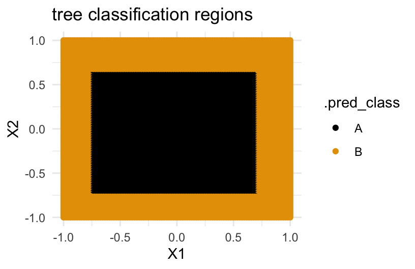

```r
# THIS IS ONLY DEMO CODE.
# Plot the tree classification regions
examples <- data.frame(X1 = seq(-1, 1, len = 100), X2 = seq(-1, 1, len = 100)) %>%
  expand.grid()
circle_tree %>%
  predict(new_data = examples) %>%
  cbind(examples) %>%
  ggplot(aes(y = X2, x = X1, color = .pred_class)) +
    geom_point() +
    labs(title = "tree classification regions") +
    theme_minimal()
```

3. If we built a **forest** model of `class` by `X1` and `X2`, what do you think the classification regions will look like?
4. Check your intuition. Were you right?

```r
# THIS IS ONLY DEMO CODE.
# Build the forest
circle_forest <- rf_spec %>%
  fit(class ~ ., data = simulated_data)
## Error in eval(expr, envir, enclos): object 'rf_spec' not found

# Plot the tree classification regions
circle_forest %>%
  predict(new_data = examples) %>%
  cbind(examples) %>%
  ggplot(aes(y = X2, x = X1, color = .pred_class)) +
    geom_point() +
    labs(title = "forest classification regions") +
    theme_minimal()
## Error in eval(expr, envir, enclos): object 'circle_forest' not found
```

[output not shown]

5. Reflect on what you’ve observed here!

## Exercise 8: If you finish early

Do one of the following:

- Check out the optional “Deeper learning” section below on another ensemble method: **boosting**. (it is one of the options for group assignment 2)
- Check out group assignment 2 on Moodle.
- Work on homework.

# Deeper learning (optional)

*Extreme gradient boosting*, or **XGBoost**, is yet another ensemble algorithm for regression and classification.

We’ll consider the big picture here.

If you want to dig deeper:

- Section 8.2.3 of the book provides a more detailed background
- Julia Silge’s [blogpost on predicting home runs](https://juliasilge.com/blog/baseball-racing/) provides an example of implementing XGBoost using `tidymodels`.

The **big picture**:

- Like bagging and forests, boosting combines predictions from B different trees.
- BUT these trees aren’t built from B different resamples. Boosting trees are grown *sequentially*, each tree *slowly learning* from the previous trees in the sequence to *improve* in areas where the previous trees didn’t do well. Loosely speaking, data points with larger misclassification rates among previous trees are given more weight in building future trees.
- Unlike in bagging and forests, trees with better performance are given more weight in making future classifications.

**Bagging vs boosting**

- Bagging typically helps decrease variance, but not bias. Thus it is useful in scenarios where other algorithms are unstable and overfit to the sample data.
- Boosting typically helps decrease bias, but not variance. Thus it is useful in scenarios where other algorithms are stable, but overly simple.

# R code

Suppose we want to build a forest or bagging algorithm of some categorical response variable `y` using predictors `x1` and `x2` in our `sample_data`.

```r
# Load packages
library(tidymodels)
library(rpart)
library(rpart.plot)

# Resolves package conflicts by preferring tidymodels functions
tidymodels_prefer()
```

**Make sure that y is a factor variable**

```r
sample_data <- sample_data %>%
  mutate(y = as.factor(y))
```

**Build the forest / bagging model**

We’ll typically use the following tuning parameters:

- `trees` = 500 (the more trees we use, the less variable the forest)
- `min_n` = 2 (the smaller we allow the leaf nodes to be, the less pruned, hence less biased our forest will be)
- `mtry`
  - for forests: `mtry = NULL` (the default) will use the “floor”, or biggest integer below, sqrt(number of predictors)
  - for bagging: set `mtry` to the number of predictors

```r
# STEP 1: Model Specification
rf_spec <- rand_forest()  %>%
  set_mode("classification") %>%
  set_engine(engine = "ranger") %>%
  set_args(
    mtry = ___,
    trees = 500,
    min_n = 2,
    probability = FALSE, # give classifications, not probability calculations
    importance = "impurity" # use Gini index to measure variable importance
  )

# STEP 2: Build the forest or bagging model
# There are no preprocessing steps or tuning, hence no need for a workflow!
ensemble_model <- rf_spec %>%
  fit(y ~ x1 + x2, data = sample_data)
```

**Use the model to make predictions / classifications**

```r
# Put in a data.frame object with x1 and x2 values (at minimum)
ensemble_model %>%
  predict(new_data = ___)
```

**Examine variable importance**

```r
# Print the metrics
ensemble_model %>%
  extract_fit_engine() %>%
  pluck("variable.importance") %>%
  sort(decreasing = TRUE)

# Plot the metrics
# Plug in the number of top predictors you wish to plot
# (The upper limit varies by application!)
library(vip)
ensemble_model %>%
  vip(geom = "point", num_features = ___)
```

**Evaluate the classifications**

```r
# Out-of-bag (OOB) prediction error
ensemble_model

# OOB confusion matrix
ensemble_model %>%
  extract_fit_engine() %>%
  pluck("confusion.matrix") %>%
  t()

# In-sample confusion matrix
ensemble_model %>%
  predict(new_data = sample_data) %>%
  cbind(sample_data) %>%
  conf_mat(
    truth = y,
    estimate = .pred_class
  )
```

## Footnotes

[^1]: citation: https://daviddalpiaz.github.io/r4sl/ensemble-methods.html#tree-versus-ensemble-boundaries